# Amazon Employee Retention Analysis

Tsung-Han Tsai

2024-12-13

# **Culture Matters: The key factors Amazon employees value**

## **Introduction & Motivation**

According to a Forbes report in October 2022, Amazon has a high attrition rate that costs the company $8 Billion annually. For any company to be successful, lowering unnecessary costs and retain their talent is crucial. Lowering high attrition rate is a great way to save money and keep the employees. And in order to do so, Amazon must identify and satisfy employees needs. This is what the project aim to do.

## **Problem Indentification**

So here comes the question, **which area should be the top priority for Amazon to make improvements?**. This project will utilize Linear Regression and Text Analysis to identify employees concern and make suggestions to Amazon for improvement.

## **Data Collection**

The dataset is the Amazon job reviews (USA India) 2008-2020 from Kaggle.

This dataset comprise of employees’ working-related data, ratings, status and their text review on the corresponding job.

In this dataset, we have **29,494** observations and **23** variables(With **1** column that named X as an Index column).

The overview of data:

Job-relating variables:

- ID number: The unique id number
- Year: The year on which the review is given
- Location: The location of office at which the review is given
- Position: The designation of employee in the company
- Current employee Whether the employee is currently on job
- Former employee: Whether the employee has left the company
- Timeline

Rating/Review-related variables:

- Comment for company: Summary of review for Amazon (Text data)
- Overall rating: The overall rating given by employee to the company out of 5
- Work/Life Balance: Rating given by work/life balance to the company out of 5
- Culture & Values: Rating given by employee on culture and values in the company out of 5
- Diversity & Inclusion: Rating given by employee on Diversity and inclusion in the company out of 5
- Career Opportunities: Rating given by employee on Career Opportunity in the company out of 5
- Compensation and Benefits: Rating given by employee on Compensation and Benefits in the company out of 5
- Senior Management: Rating given by employee on Senior Management in the company out of 5
- CEO Approval
- Recommended: Whether the employee recommends the job
- cons: Disadvantage of the job (Text data)
- pros: Advantage of the job (Text data)
- advice to Management
- review_url: The link to the review

## **Data Preparation**

```r
# Loading the packages
library(dplyr)
library(tidyr)
library(ggplot2)
library(gridExtra)
library(caret)
library(corrplot)
library(stringdist)
library(tidytext)
library(textclean)
library(tm)
library(SnowballC)
library(textstem)
library(stringr)
library(hunspell)
library(tidyr)
library(wordcloud)
library(syuzhet)
library(topicmodels)
```

```r
# Loading the dataset
amazon <- read.csv("Amazon_Job_Reviews.csv")
```

#### **Data labeling and Selecting**

In order to make the analysis close to reality, I only selected the reviews within 2020, which are the latest review in the dataset.

```r
# To make the analysis represent closely to the current status, we only select the 2020 reviews to analyze
amazon_2020 <- amazon |>
  filter(as.integer(Year) > 2019)
```

```r
head(amazon_2020)
```

```
##       X ID.number                         Location                    Position
## 1 13659     13660                      Livonia, MI         Warehouse Associate
## 2 13660     13661                      Herndon, VA  Customer Service Associate
## 3 13661     13662                       Dallas, TX         Warehouse Associate
## 4 13662     13663 Sparrows Point, MD, Optional[MD]         Warehouse Associate
## 5 13663     13664                     Chandler, AZ                      Amazon
## 6 13664     13665                      Seattle, WA             Program Manager
##                              Comment.for.company Overall.ratting
## 1                                           Easy               4
## 2                              Flexible Schedule               5
## 3                               Do not work here               1
## 4 Nice for extra cash. Not advancing your carrer               2
## 5         Flexible Work Hours, Great Environment               4
## 6                     Do your time, then get out               2
##   Work.Life.Balance Culture...Values Diversity...Inclusion Career.Opportunities
```

[output cut: 55 more lines]

There is a **Location** variable that represents the city where the employee works, to simplify the analysis process, I mapped the cities to their corresponding countries, which is either the USA or India.

```r
# Processing the Location, mapping locations to Country. Either in USA or India
# List of valid US state codes
us_state_codes <- c("AL", "AK", "AZ", "AR", "CA", "CO", "CT", "DC", "DE", "FL", "GA", "HI", "ID", "IL", "IN", "IA", "KS",
                    "KY", "LA", "ME", "MD", "MA", "MI", "MN", "MS", "MO", "MT", "NE", "NV", "NH", "NJ", "NM", "NY", "NC",
                    "ND", "OH", "OK", "OR", "PA", "RI", "SC", "SD", "TN", "TX", "UT", "VT", "VA", "WA", "WV", "WI", "WY")

# Function to map location to country
map_country <- function(location) {
  # Check if the location contains a comma
  if (grepl(",", location)) {
    # Split by comma to get city and state
    parts <- strsplit(location, ",")[[1]]
    city <- trimws(parts[1])
    state <- trimws(parts[2])

    # Check if the state is in the list of valid US state codes
    if (state %in% us_state_codes) {
      return("USA")
    } else {
      return("India")
    }
  } else {
    # If there's no comma, label as India
    return("India")
  }
}

# Apply the function to the 'Location' column and create a new 'Country' column
amazon_2020$Country <- sapply(amazon_2020$Location, map_country)
```

```r
table(amazon_2020$Country)
```

```
##
## India   USA
##  3260  7044
```

Based on the distribution above we can see that the majority of the reviews in 2020 comes from United States of America.

Moreover, there are multiple job positions in **position** column, to be able to identify patterns and differences in the analysis, I decided to map the position to corresponding department based on the position’s function. Thus creating a **department** column.

```r
# Create a new column that represent the employees department based on their Position
# Load necessary libraries
library(dplyr)

# Example: If your data is in a CSV file
# amazon_positions <- read.csv("unique_amazon_positions_2020.csv", stringsAsFactors = FALSE)

# Function to categorize positions into departments
categorize_position <- function(position) {
  position <- tolower(trimws(position)) # Convert to lowercase and remove whitespace

  if (grepl("warehouse|operations|logistics|fulfillment|delivery", position)) {
    return("Operations")
  } else if (grepl("customer service|support", position)) {
    return("Customer Service")
  } else if (grepl("manager|director|lead|program|project", position)) {
    return("Corporate/Management")
  } else if (grepl("software|data|engineer|developer|scientist|technology|tech|it|analyst", position)) {
    return("Technology")
  } else {
    return("Other")
  }
}

# Apply the categorization function to the dataset
amazon_2020 <- amazon_2020 %>%
  mutate(Department = sapply(Position, categorize_position))

# See the distribution
table(amazon_2020$Department)
```

```
##
## Corporate/Management     Customer Service           Operations
##                 1180                  825                 2137
##                Other           Technology
##                 4314                 1848
```

As we can see, there are a lot of employees working in functions like **Management**, **Operations** and **Technology** which reflects my perception about Amazon, an multinational technology corporation.

Since I will conduct Linear Regression and Text Analysis in this project, I will separate the project into 2 sections, **Linear Regression Analysis** and **Text Analysis**

## **Linear Regression Analysis**

I want to analyze the impact of different rating categories on the overall rating to identify which area is the most important factor that Amazon employees value, and require prioritized improvement by the company.

### **Data Preparation: Processing**

1. Separating the dataset

```r
# Separating the dataset
amazon_reg_data <- amazon_2020[, c(1, 6:12, 24:25)]

# Printing the size of the dataset
dim(amazon_reg_data)
```

```
## [1] 10304    10
```

```r
# There are 10304 rows of reviews with 10 variables
```

2. Detecting & Handling Duplicate Rows

```r
# Detecting and remove duplicate values
amazon_reg_data <- amazon_reg_data %>%
  distinct()

# Printing the size of the dataset
dim(amazon_reg_data)
```

```
## [1] 10304    10
```

```r
# There is no duplicate values
```

3. Detecting and Handling Missing Values

```r
# Detecting missing values
missing_summary_reg <- data.frame(
  Column = names(amazon_reg_data),
  MissingValues = colSums(is.na(amazon_reg_data)),
  MissingPercentage = colMeans(is.na(amazon_reg_data)) * 100
)
missing_summary_reg
```

```
##                                              Column MissingValues
## X                                                 X             0
## Overall.ratting                     Overall.ratting             0
## Work.Life.Balance                 Work.Life.Balance          2034
## Culture...Values                   Culture...Values          2075
## Diversity...Inclusion         Diversity...Inclusion          6483
## Career.Opportunities           Career.Opportunities          2000
## Compensation.and.Benefits Compensation.and.Benefits          2023
## Senior.Management                 Senior.Management          2132
## Country                                     Country             0
## Department                               Department             0
##                           MissingPercentage
## X                                   0.00000
## Overall.ratting                     0.00000
## Work.Life.Balance                  19.73991
## Culture...Values                   20.13781
## Diversity...Inclusion              62.91731
## Career.Opportunities               19.40994
## Compensation.and.Benefits          19.63315
## Senior.Management                  20.69099
## Country                             0.00000
## Department                          0.00000
```

There are some missing values in certain columns, for the integrity of the Linear Regression Analysis, we will delete all missing values.

```r
# Deleting the missing values
amazon_reg_data <- amazon_reg_data %>%
  drop_na()
dim(amazon_reg_data)
```

```
## [1] 3734   10
```

Due to substantial missing values in some columns, there are only 3734 reviews suitable for Linear Regression Analysis.

### **Data Preparation: EDA**

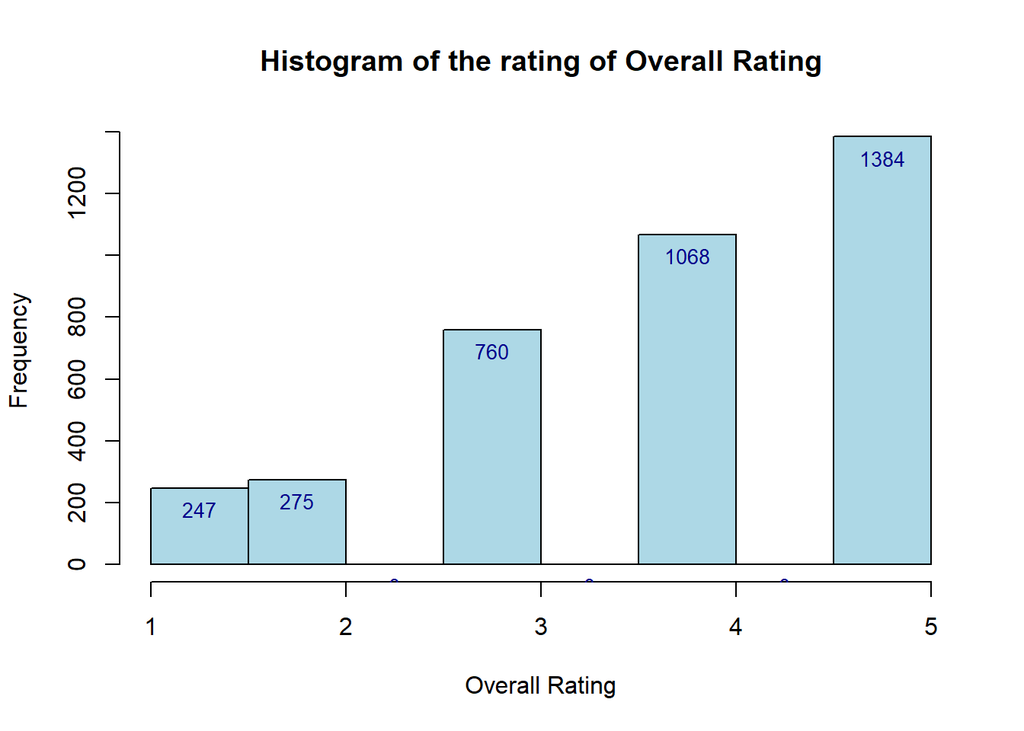

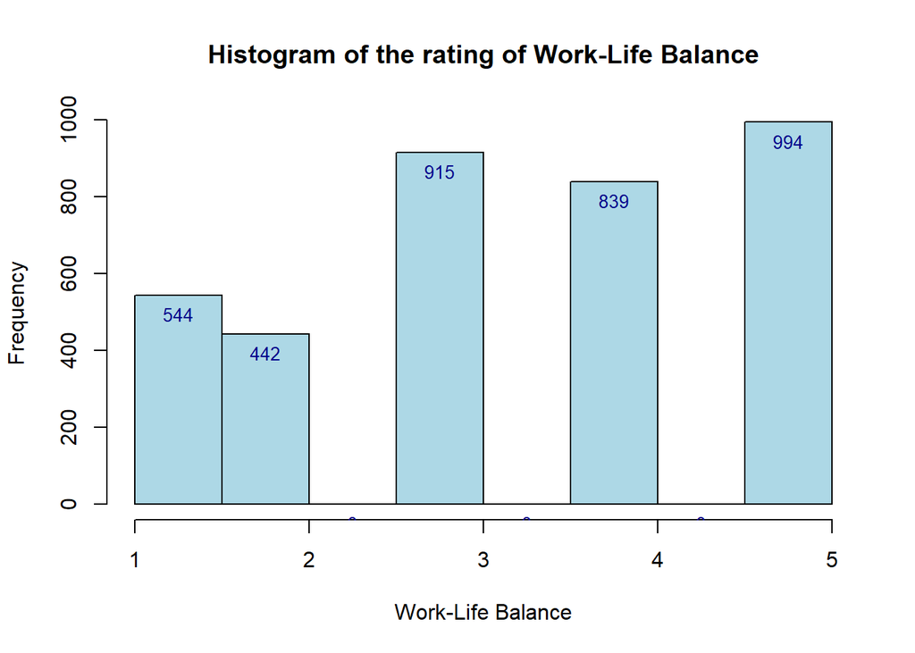

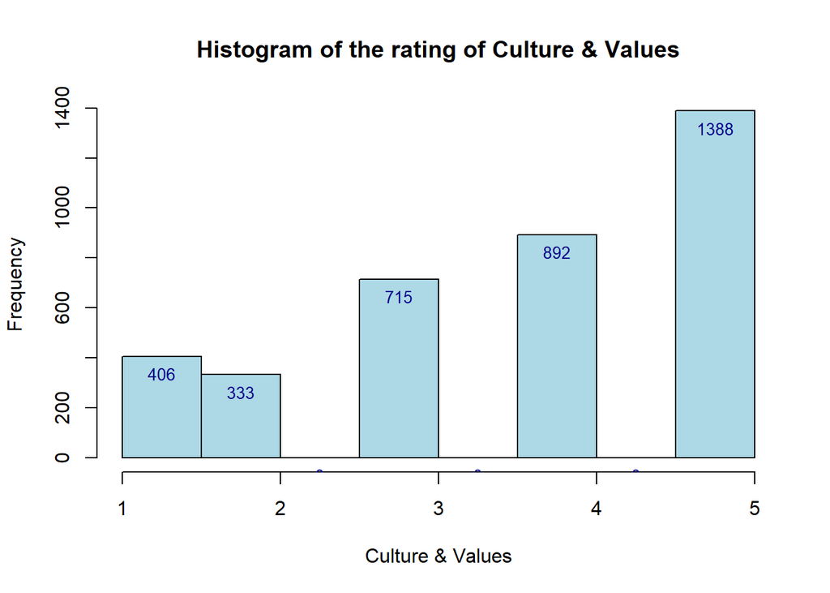

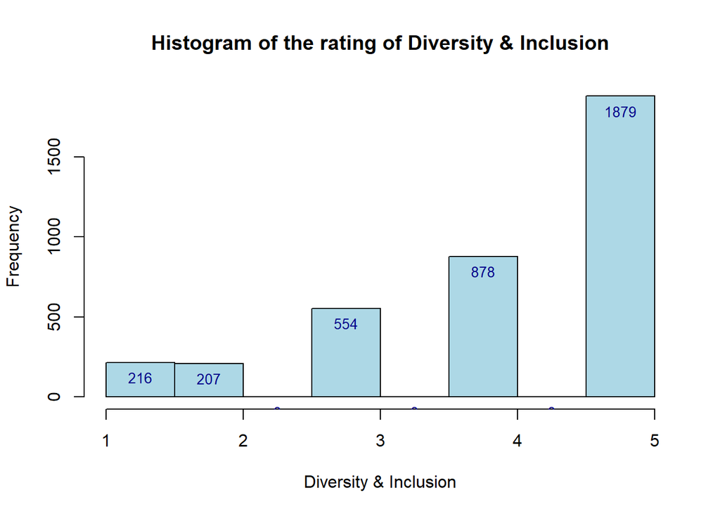

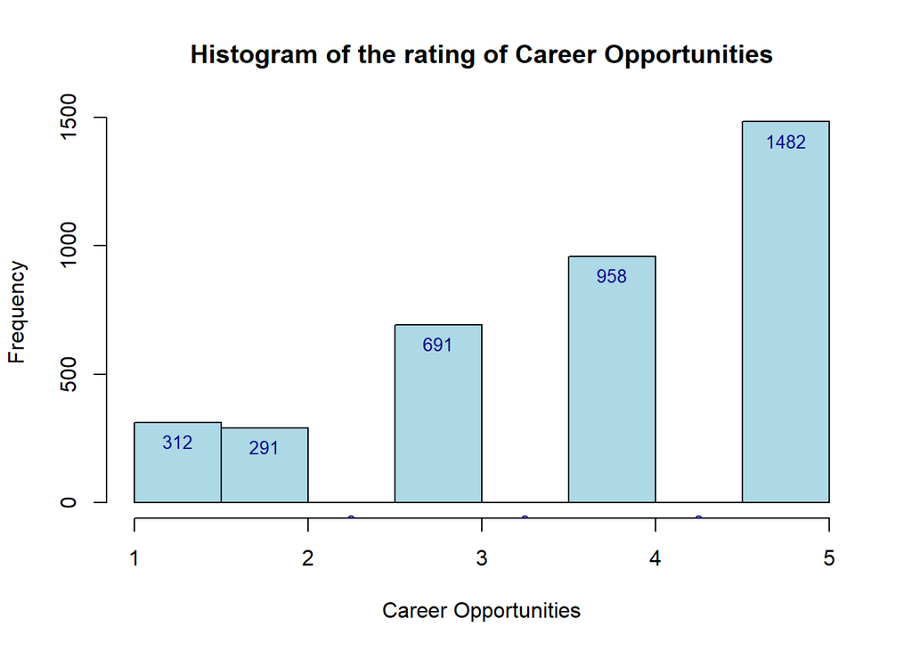

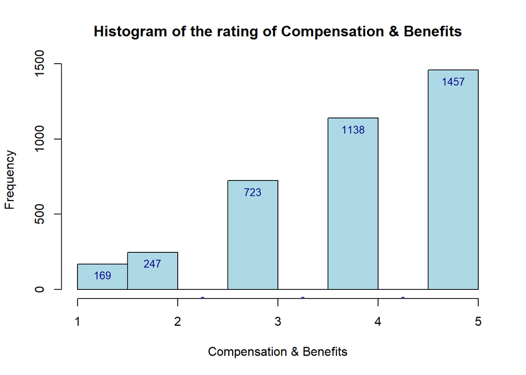

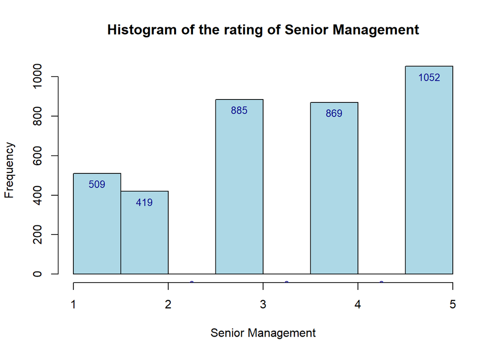

```r
# Continuous Variable: Ratings
reg_name_con <- c("Overall Rating", "Work-Life Balance", "Culture & Values", "Diversity & Inclusion",
                  "Career Opportunities", "Compensation & Benefits", "Senior Management")

for(i in 1:ncol(amazon_reg_data[, 2:8])) {
  # Plot histogram for each variable
  hist_data <- amazon_reg_data[, 2:8][[i]]
  hist_res <- hist(hist_data,
                   main = paste("Histogram of the rating of", reg_name_con[i]),
                   xlab = reg_name_con[i],
                   plot = FALSE)  # 不立即繪製，只計算數據

  # Calculate the positions and frequencies of the bars
  bar_positions <- hist_res$mids
  freq <- hist_res$counts

  # Plot the histogram
  hist(hist_data,
       main = paste("Histogram of the rating of", reg_name_con[i]),
       xlab = reg_name_con[i],
       col = "lightblue")

  # Add frequency numbers above the bars
  text(x = bar_positions, y = freq, labels = freq, pos = 1, cex = 0.85, col = "darkblue")
}
```

**Interpretation**:

According to the ratings’ distribution, we can see that while some ratings are poor, most of the ratings are **between 3 to 5**, which is a decent rating. But we need to keep and eye out on the rating of **Work-Life Balance** and **Senior Management**, as there frequency of rating score 1 or 2 are higher than other categories.

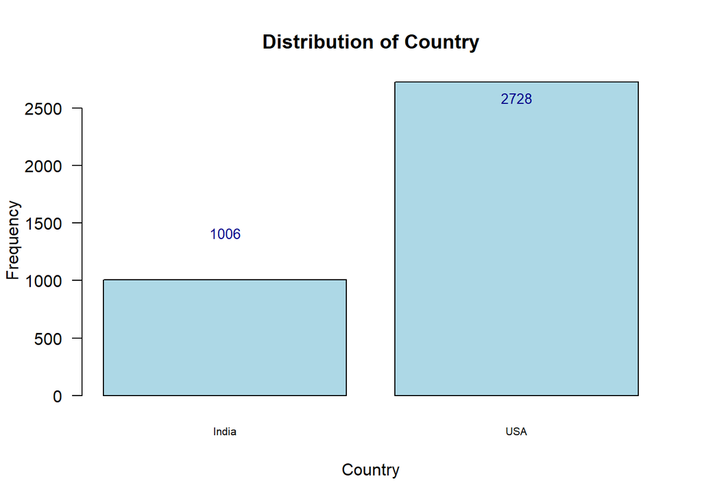

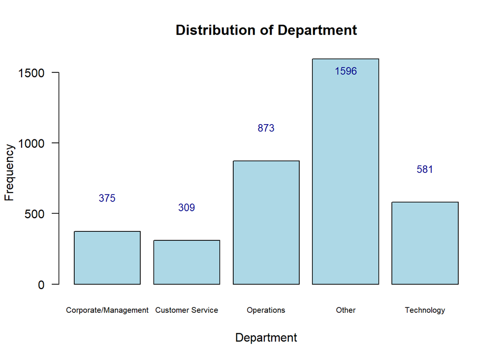

```r
# Categorical Variables: Country and Departments
for (i in 1:ncol(amazon_reg_data[, 9:10])) {
  # Calculate the frequency of each unique value
  freq <- table(amazon_reg_data[, 9:10][[i]])

  # Plot the bar graph
  bar_positions <- barplot(freq,
                           main = paste("Distribution of", names(amazon_reg_data)[i + 8]),
                           xlab = names(amazon_reg_data)[i + 8],
                           ylab = "Frequency",
                           col = "lightblue",
                           las = 1,     # Rotate y-axis labels to horizontal
                           cex.names = 0.65)

  text_positions <- ifelse(freq > max(freq) * 0.8, freq - max(freq) * 0.1, freq + max(freq) * 0.1)
  # Add the frequency numbers above the bars
  text(x = bar_positions, y = text_positions, labels = freq, pos = 3, cex = 0.85, col = "darkblue")

}
```

**Interpretation**:

In the bar-plot above, we can see **the majority of the reviews are from US employees**. Roughly **2.7 times** the reviews of India Employees. As for department, most of the employees are in **Operations** and **Technology**. Be aware that the **others** contain positions such as Security Guard, Problem solver or even Interns, so I will not emphasize on elaborating or analyzing **Other** departments.

Rating Distribution between Country & Department

**Country wise**

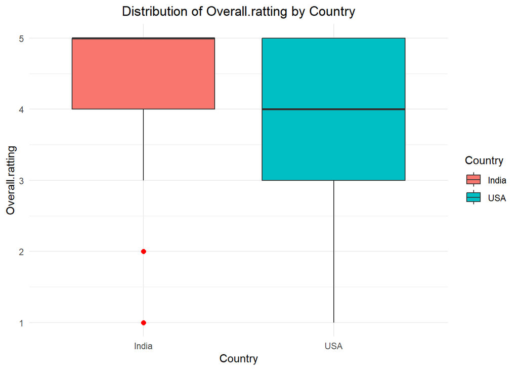

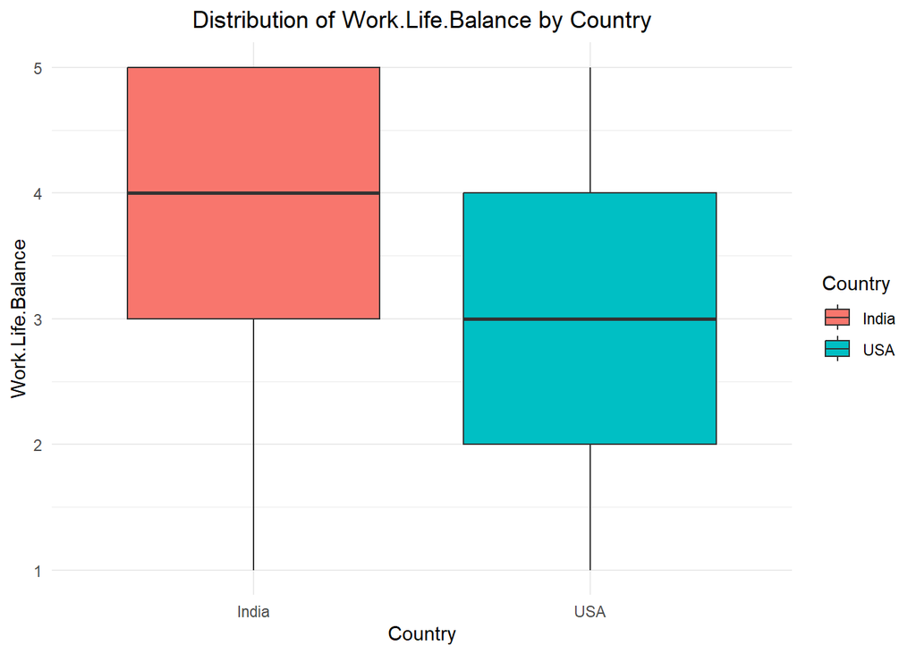

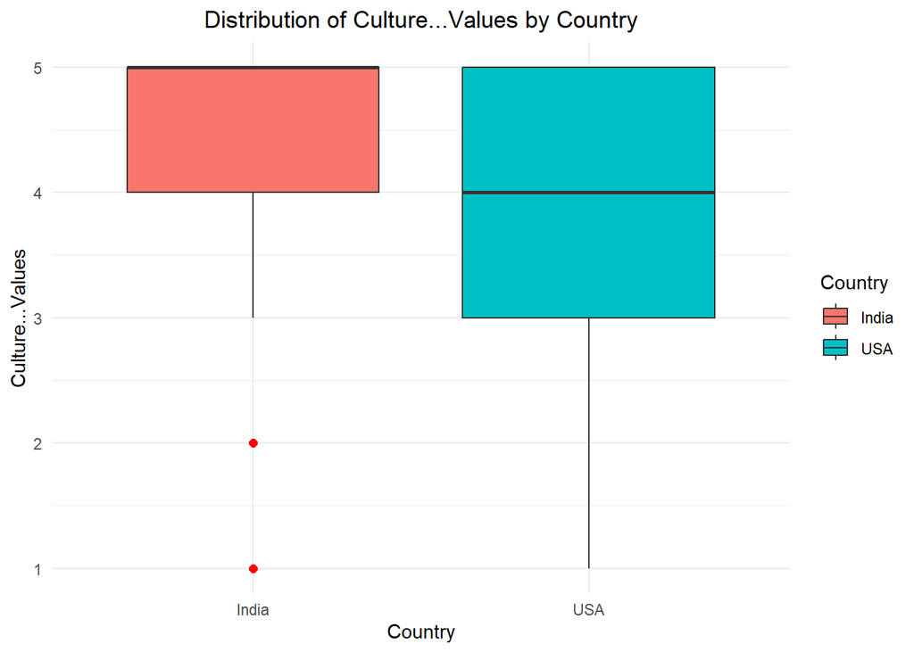

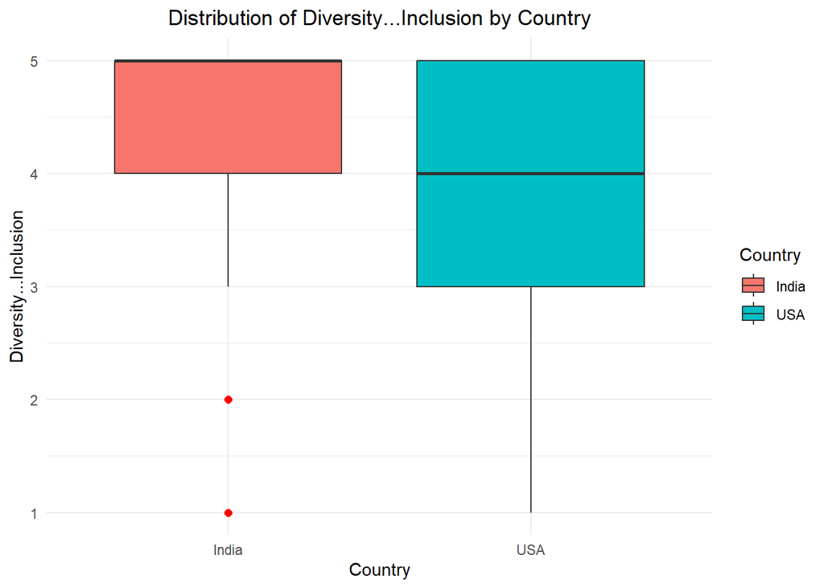

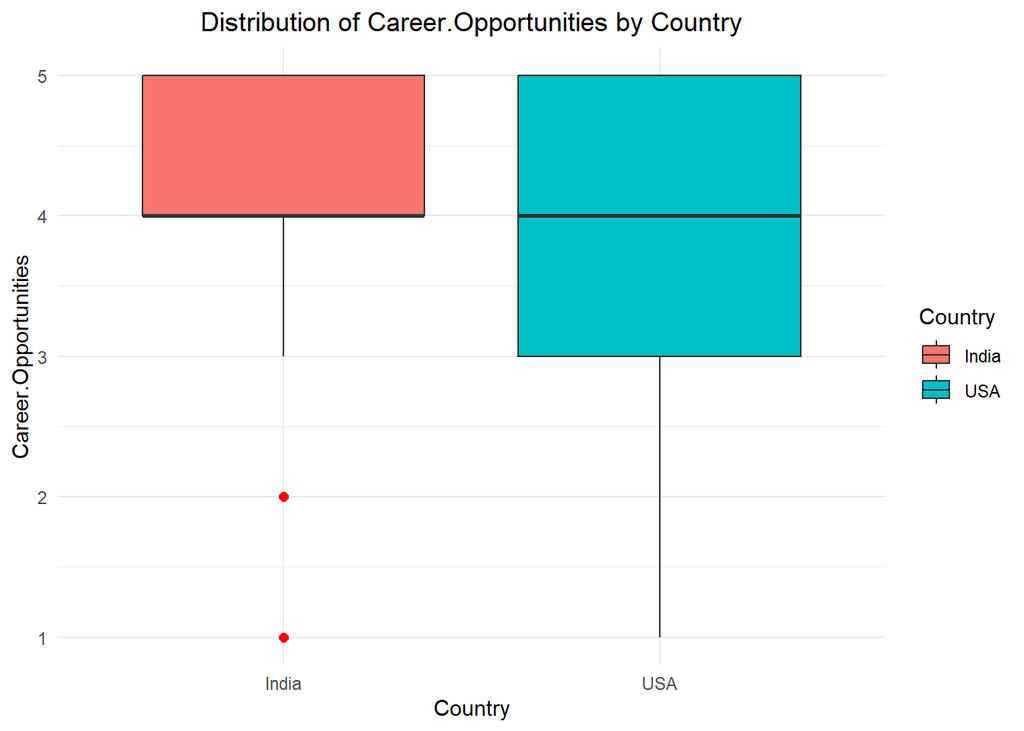

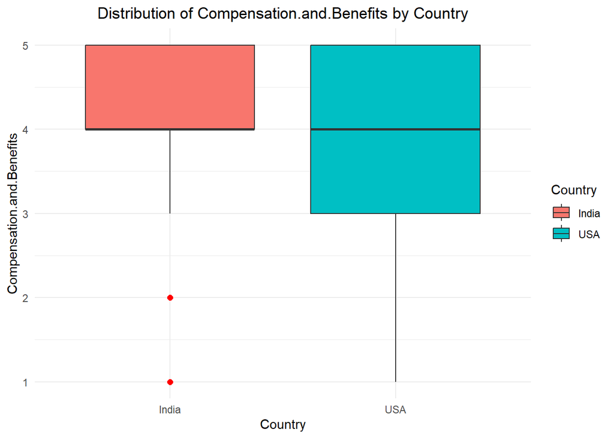

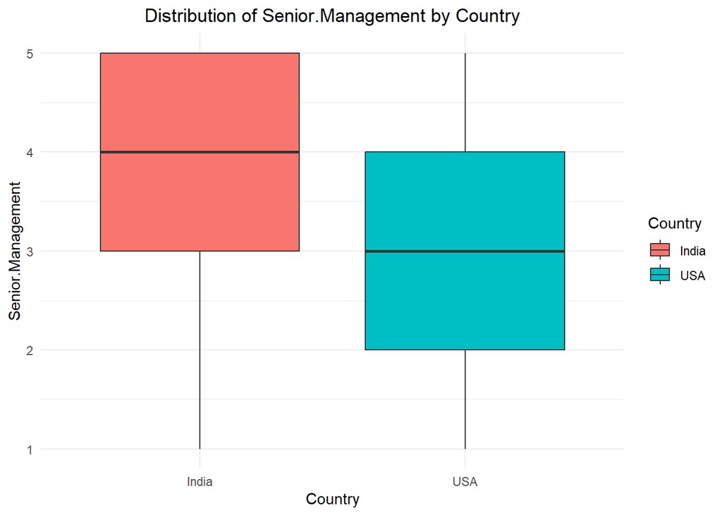

```r
# 需要比較的 Rating 變數
ratings <- c("Overall.ratting", "Work.Life.Balance", "Culture...Values", "Diversity...Inclusion",
             "Career.Opportunities", "Compensation.and.Benefits", "Senior.Management")

# 繪製每個 Rating 基於國家的分佈
for (rating in ratings) {
  p_country <- ggplot(amazon_reg_data, aes(x = Country, y = .data[[rating]], fill = Country)) +
    geom_boxplot(outlier.colour = "red", outlier.shape = 16, outlier.size = 2) +
    labs(title = paste("Distribution of", rating, "by Country"),
         x = "Country", y = rating) +
    theme_minimal() +
    theme(plot.title = element_text(hjust = 0.5)) # 標題置中
  print(p_country)
}
```

Interpretation: According to the box-plot above we can see that **overall employees in India rated higher in almost each categories except Career Opportunities and Compensation & Benefits**. Since there seems to be some difference in ratings among countries. We will dive deep into Linear Regression Analysis between countries.

**Department wise**

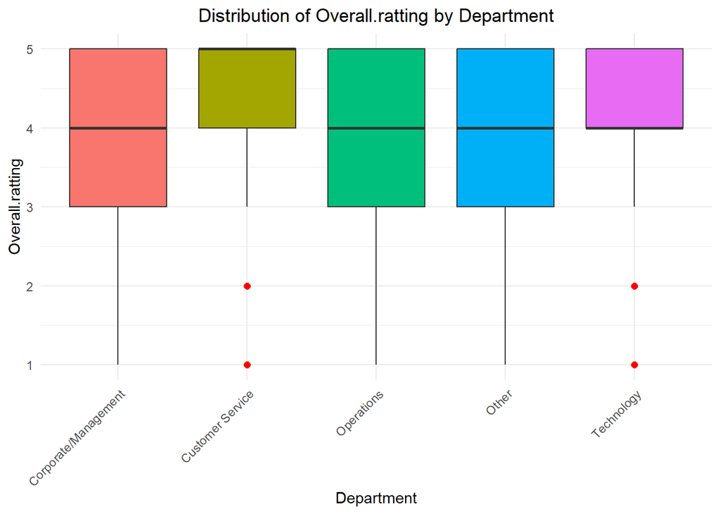

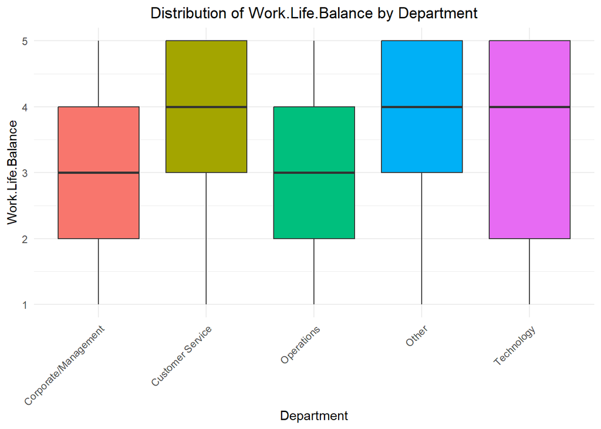

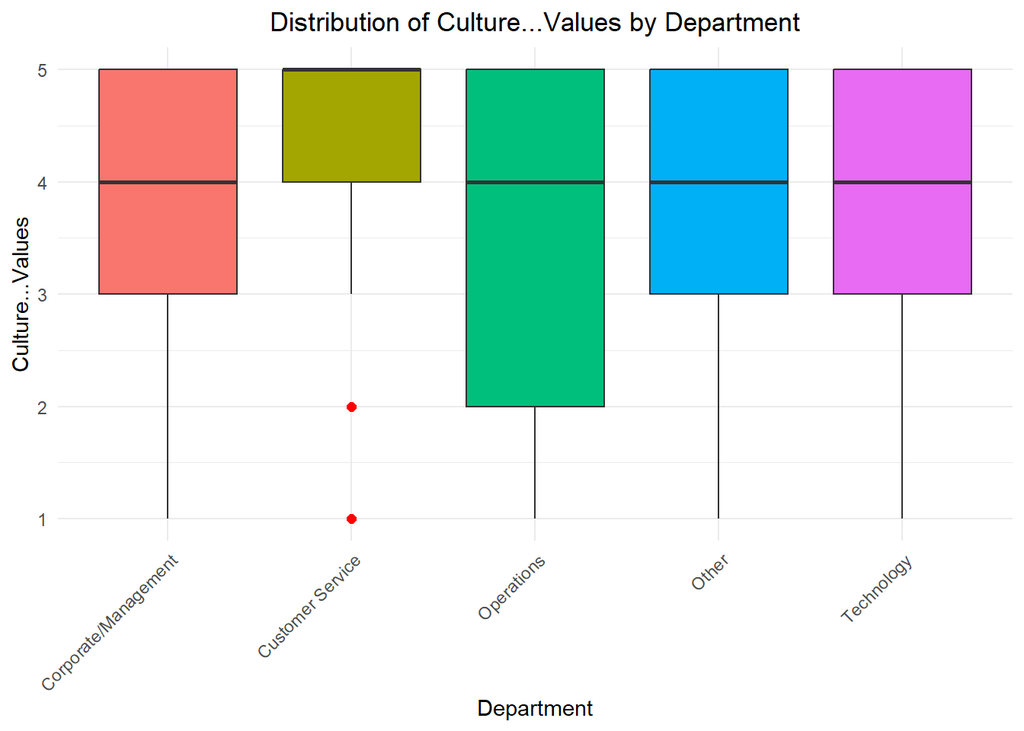

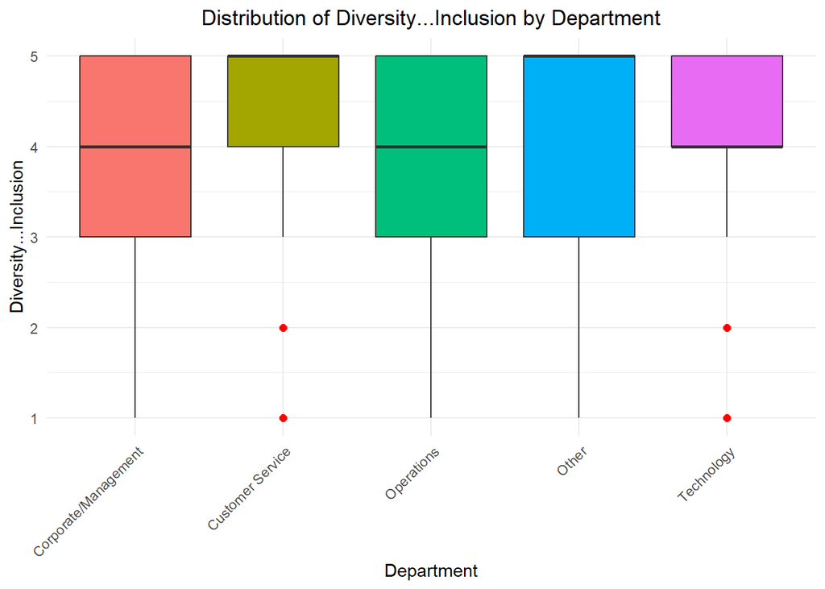

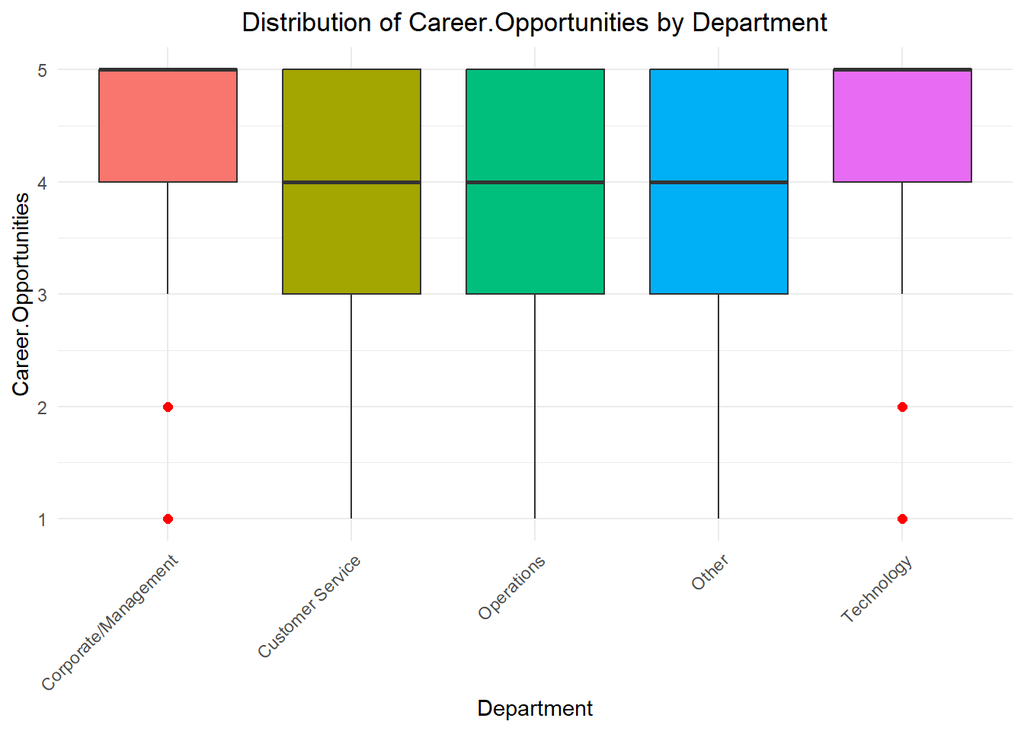

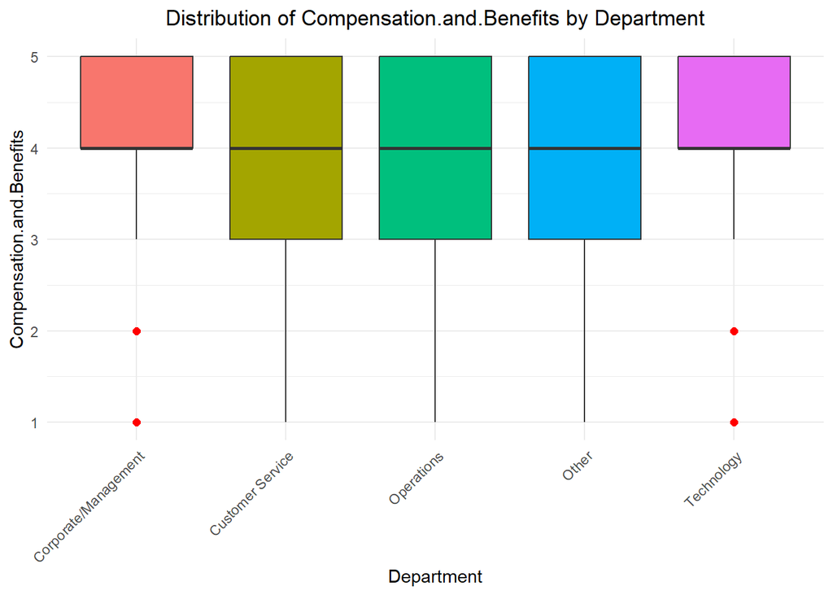

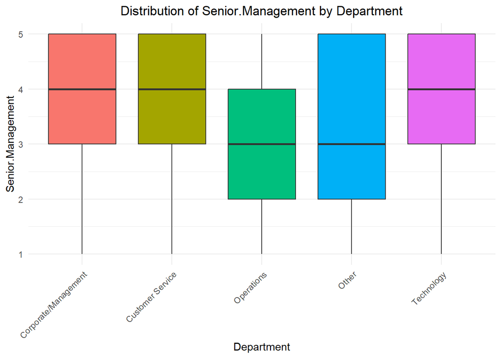

```r
# Drawing box-plot based on departments
for (rating in ratings) {
  p_department <- ggplot(amazon_reg_data, aes(x = Department, y = .data[[rating]], fill = Department)) +
    geom_boxplot(outlier.colour = "red", outlier.shape = 16, outlier.size = 2) +
    labs(title = paste("Distribution of", rating, "by Department"),
         x = "Department", y = rating) +
    theme_minimal() +
    theme(axis.text.x = element_text(angle = 45, hjust = 1)) +
    theme(plot.title = element_text(hjust = 0.5),
          legend.position = "none")
  print(p_department)
}
```

According to the department based box-plot, we can see that **there are differences among the departments**. As a consequence, we will also dive deep into departments during the linear regression analysis.

**Correlation**

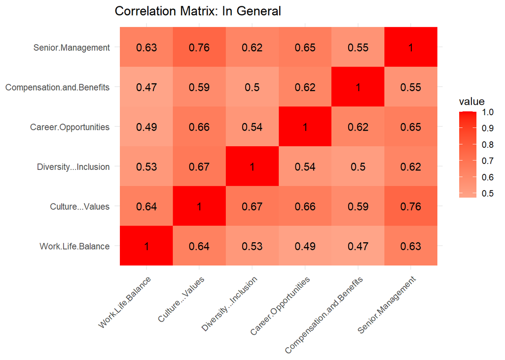

```r
# Load required packages
library(ggplot2)
library(reshape2)

# Calculate correlations excluding categorical variables
cor_matrix_gen <- cor(subset(amazon_reg_data, select = -c(X, Overall.ratting, Country, Department)))
# Melt the matrix for ggplot2
melted_cor <- melt(cor_matrix_gen)

# Plot heatmap
ggplot(data = melted_cor, aes(x=Var1, y=Var2, fill=value)) +
  geom_tile() +
  geom_text(aes(label=round(value, 2))) +
  scale_fill_gradient2(low="blue", high="red", mid="white", midpoint=0) +
  theme_minimal() +
  theme(axis.text.x = element_text(angle = 45, hjust = 1)) + # 調整角度和對齊方式
  labs(title = "Correlation Matrix: In General", x = NULL, y = NULL)
```

Interpretation: All the independent variables are not highly correlated, so **we can add them into the linear regression model without having to deal with multicollinearity**.

But do notice that the correlation between **Culture&Values** and **Senior Management** is **0.76**, so during the interpretation of the project results, there might be results that combined these 2 characteristics together.

Conclusion: According to above Exploratory Data Analysis, we can see that **there is a difference in ratings among countries and departments**. Therefore, I will conduct linear regression **based on countries and departments** to find which areas affect the overall ratings the most**.

### **Data Analysis**

First, I want to create a **general model** that reflects an overview of the coefficient and significance.

```r
# Creating a general model
overall_model <- lm(Overall.ratting ~ Work.Life.Balance + Culture...Values + Diversity...Inclusion + Career.Opportunities + Compensation.and.Benefits + Senior.Management,
              data = amazon_reg_data)
summary(overall_model)
```

```
##
## Call:
## lm(formula = Overall.ratting ~ Work.Life.Balance + Culture...Values +
##     Diversity...Inclusion + Career.Opportunities + Compensation.and.Benefits +
##     Senior.Management, data = amazon_reg_data)
##
## Residuals:
##     Min      1Q  Median      3Q     Max
## -4.0440 -0.3411 -0.0440  0.3546  3.6114
##
## Coefficients:
##                           Estimate Std. Error t value Pr(>|t|)
## (Intercept)                0.47472    0.04504  10.540  < 2e-16 ***
## Work.Life.Balance          0.12350    0.01077  11.462  < 2e-16 ***
## Culture...Values           0.28866    0.01438  20.077  < 2e-16 ***
## Diversity...Inclusion      0.04875    0.01281   3.804 0.000145 ***
## Career.Opportunities       0.22063    0.01254  17.591  < 2e-16 ***
## Compensation.and.Benefits  0.08075    0.01297   6.227  5.3e-10 ***
## Senior.Management          0.15157    0.01333  11.369  < 2e-16 ***
## ---
## Signif. codes:  0 '***' 0.001 '**' 0.01 '*' 0.05 '.' 0.1 ' ' 1
##
## Residual standard error: 0.6533 on 3727 degrees of freedom
## Multiple R-squared:  0.7025, Adjusted R-squared:  0.7021
## F-statistic:  1467 on 6 and 3727 DF,  p-value: < 2.2e-16
```

According to the general model, **under the significance level of 0.05**, **all of the ratings from different aspects in jobs are significant.**

But based on the result of Exploratory Data Analysis, we still **need to dive deep into countries and departments** to identify which areas affect the overall ratings the most.

Let’s see how the regression results among countries look like:

```r
# Getting unique country values
countries <- unique(amazon_reg_data$Country)

# 按國家進行線性回歸
models_by_country <- list()
models_countries <- list()

for (country in countries) {

  country_data <- amazon_reg_data[amazon_reg_data$Country == country, ]

  # Conducting Linear Regression
  model_country <- lm(Overall.ratting ~ Work.Life.Balance + Culture...Values + Diversity...Inclusion + Career.Opportunities + Compensation.and.Benefits + Senior.Management,
              data = country_data)


  country_summary <- summary(model_country)

  # Storing Coefficients
  country_coeffs <- data.frame(
    Country = country,
    Variable = rownames(country_summary$coefficients),
    Estimate = country_summary$coefficients[, 1],
    Std.Error = country_summary$coefficients[, 2],
    t.value = country_summary$coefficients[, 3],
    P.Value = country_summary$coefficients[, 4]
  )

  models_by_country[[country]] <- country_coeffs
  models_countries[[country]] <- model_country
}


country_results <- bind_rows(models_by_country)


model_1 <- models_countries[["USA"]]
model_2 <- models_countries[["India"]]

# Using stargazer to compare results
library(stargazer)
stargazer(model_1, model_2, type = "text",
          dep.var.labels = "Overall Rating",
          column.labels = c("USA", "India"),
          out = "model_comparison.html")
```

```
##
## ==============================================================================
##                                           Dependent variable:
##                           ----------------------------------------------------
##                                              Overall Rating
##                                       USA                      India
##                                       (1)                       (2)
## ------------------------------------------------------------------------------
## Work.Life.Balance                  0.121***                   0.140***
##                                     (0.013)                   (0.020)
##
## Culture...Values                   0.274***                   0.197***
##                                     (0.017)                   (0.029)
##
## Diversity...Inclusion              0.044***                   0.118***
##                                     (0.014)                   (0.029)
##
## Career.Opportunities               0.227***                   0.183***
##                                     (0.015)                   (0.024)
##
## Compensation.and.Benefits          0.073***                   0.133***
##                                     (0.015)                   (0.025)
##
## Senior.Management                  0.174***                   0.086***
##                                     (0.016)                   (0.023)
##
## Constant                           0.451***                   0.799***
##                                     (0.051)                   (0.098)
##
## ------------------------------------------------------------------------------
## Observations                         2,728                     1,006
## R2                                   0.701                     0.619
## Adjusted R2                          0.700                     0.617
## Residual Std. Error            0.676 (df = 2721)          0.566 (df = 999)
## F Statistic               1,061.443*** (df = 6; 2721) 270.439*** (df = 6; 999)
## ==============================================================================
## Note:                                              *p<0.1; **p<0.05; ***p<0.01
```

We can see that regardless of country, the variables in USA and India model **are all significant** under 0.05 confidence level.

Let’s check the departments.

```r
library(stargazer)

departments <- unique(amazon_reg_data$Department)


models_by_department <- list()
models_department <- list()

for (department in departments) {

  department_data <- amazon_reg_data[amazon_reg_data$Department == department, ]


  model_dep <- lm(Overall.ratting ~ Work.Life.Balance + Culture...Values + Diversity...Inclusion + Career.Opportunities + Compensation.and.Benefits + Senior.Management,
              data = department_data)


  dep_summary <- summary(model_dep)


  dep_coeffs <- data.frame(
    Department = department,
    Variable = rownames(dep_summary$coefficients),
    Estimate = dep_summary$coefficients[, 1],
    Std.Error = dep_summary$coefficients[, 2],
    t.value = dep_summary$coefficients[, 3],
    P.Value = dep_summary$coefficients[, 4]
  )

  models_by_department[[department]] <- dep_coeffs
  models_department[[department]] <- model_dep
}


department_results <- bind_rows(models_by_department)


model_d1 <- models_department[["Corporate/Management"]]
model_d2 <- models_department[["Customer Service"]]
model_d3 <- models_department[["Operations"]]
model_d4 <- models_department[["Other"]]
model_d5 <- models_department[["Technology"]]


stargazer(model_d1, model_d2, model_d3, model_d4, model_d5, type = "text",
          dep.var.labels = "Overall Rating",
          column.labels = c("Corporate/Management", "Customer Service" , "Operations", "Other" , "Technology"),
          out = "model_comparison.html")
```

```
##
## =======================================================================================================================================================
##                                                                                Dependent variable:
##                           -----------------------------------------------------------------------------------------------------------------------------
##                                                                                  Overall Rating
##                             Corporate/Management       Customer Service            Operations                  Other                  Technology
##                                     (1)                      (2)                      (3)                       (4)                      (5)
## -------------------------------------------------------------------------------------------------------------------------------------------------------
## Work.Life.Balance                 0.114***                 0.201***                 0.127***                 0.104***                  0.164***
##                                   (0.031)                  (0.035)                  (0.022)                   (0.017)                  (0.030)
##
## Culture...Values                  0.288***                 0.381***                 0.281***                 0.274***                  0.253***
##                                   (0.040)                  (0.049)                  (0.028)                   (0.024)                  (0.040)
##
## Diversity...Inclusion             0.077**                   -0.049                  0.075***                  0.043**                  0.077**
##                                   (0.034)                  (0.055)                  (0.024)                   (0.021)                  (0.038)
##
## Career.Opportunities              0.232***                 0.209***                 0.196***                 0.239***                  0.154***
##                                   (0.038)                  (0.040)                  (0.025)                   (0.020)                  (0.036)
##
## Compensation.and.Benefits          0.070*                   0.091*                  0.108***                 0.058***                  0.107***
##                                   (0.036)                  (0.047)                  (0.024)                   (0.021)                  (0.034)
##
## Senior.Management                 0.159***                 0.081**                  0.130***                 0.180***                  0.138***
##                                   (0.038)                  (0.040)                  (0.027)                   (0.022)                  (0.035)
##
## Constant                          0.427***                 0.556***                 0.405***                 0.520***                  0.616***
##                                   (0.146)                  (0.175)                  (0.082)                   (0.073)                  (0.127)
##
## -------------------------------------------------------------------------------------------------------------------------------------------------------
## Observations                        375                      309                      873                      1,596                     581
## R2                                 0.752                    0.684                    0.719                     0.685                    0.665
## Adjusted R2                        0.748                    0.678                    0.718                     0.684                    0.662
## Residual Std. Error           0.562 (df = 368)         0.622 (df = 302)         0.641 (df = 866)         0.689 (df = 1589)         0.633 (df = 574)
## F Statistic               186.132*** (df = 6; 368) 108.953*** (df = 6; 302) 370.183*** (df = 6; 866) 575.252*** (df = 6; 1589) 189.996*** (df = 6; 574)
## =======================================================================================================================================================
## Note:                                                                                                                       *p<0.1; **p<0.05; ***p<0.01
```

According to the result, **almost all of the variables are significant** to **Overall Rating(Target Variable)** under 0.05 significance level.

I combine the results to make comparison much easier.

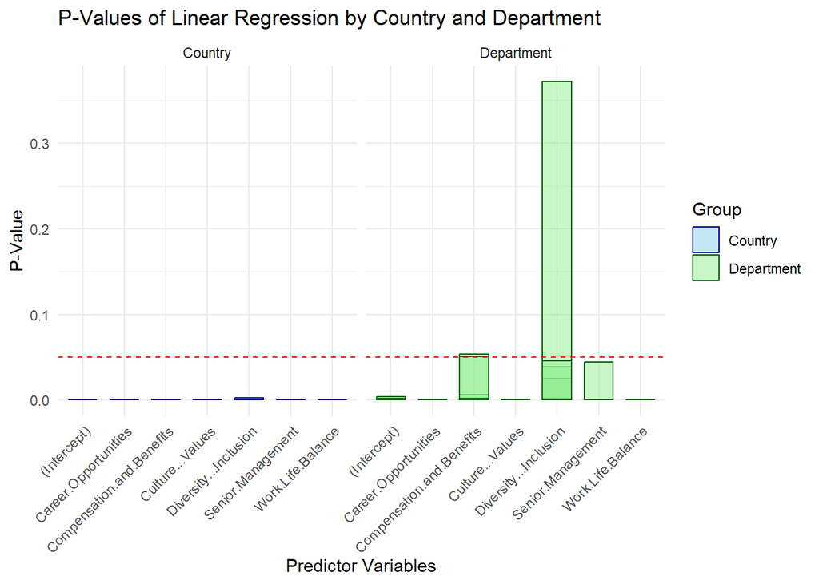

```r
# Combining coutries' and departments' results
combined_results <- bind_rows(country_results %>% mutate(Group = "Country"),
                              department_results %>% mutate(Group = "Department"))

# Visualizing the p-value
ggplot(combined_results, aes(x = Variable, y = P.Value, color = Group, fill = Group)) +
  geom_bar(stat = "identity", position = position_dodge(width = 0.8), width = 0.7, alpha = 0.5) +
  facet_wrap(~ Group, scales = "free_x") +
  geom_hline(yintercept = 0.05, linetype = "dashed", color = "red") +
  theme_minimal() +
  theme(axis.text.x = element_text(angle = 45, hjust = 1)) +
  labs(title = "P-Values of Linear Regression by Country and Department",
       x = "Predictor Variables", y = "P-Value") +
  scale_fill_manual(values = c("skyblue", "lightgreen")) +
  scale_color_manual(values = c("darkblue", "darkgreen"))
```

Based on the **p-value visualization chart**, under the **significance level of 0.05**, we can see that for **countries**, whether the USA or India, **all of the aspects of job rating** are going to affect the overall rating.

Thus, we will proceed on assessing the effect of each aspect of job ratings based on the **size of their coefficient**.

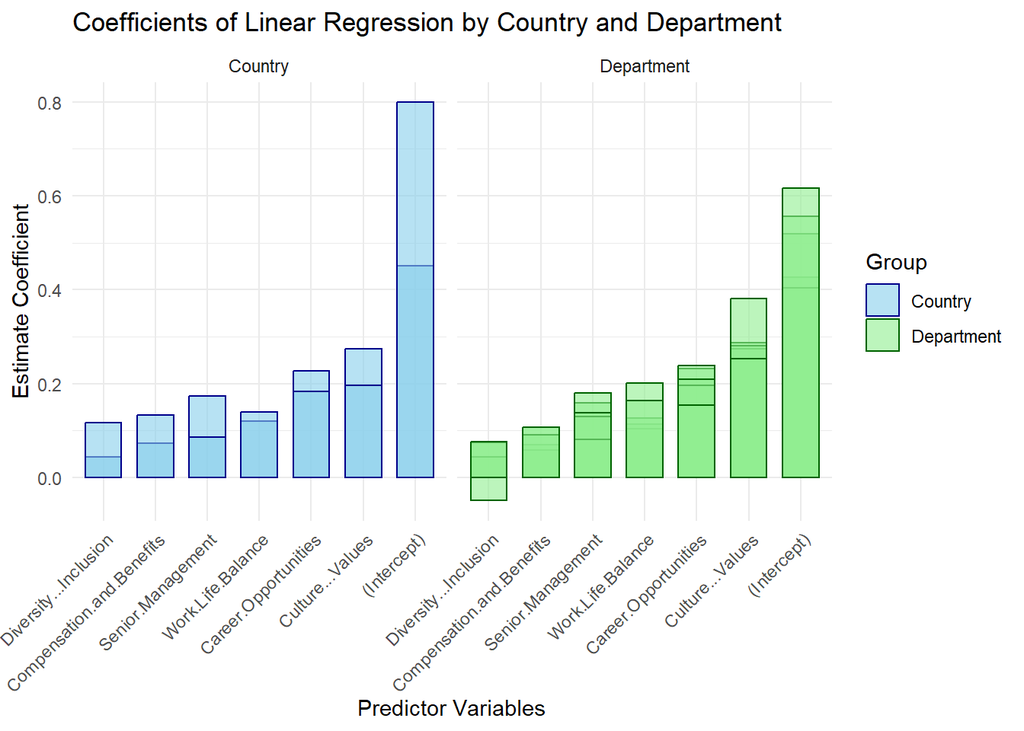

```r
# Visualizing coefficients
ggplot(combined_results, aes(x = reorder(Variable, Estimate), y = Estimate, color = Group, fill = Group)) +
  geom_bar(stat = "identity", position = position_dodge(width = 0.8), width = 0.7, alpha = 0.6) +
  facet_wrap(~ Group, scales = "free_x") +
  theme_minimal() +
  theme(axis.text.x = element_text(angle = 45, hjust = 1)) +
  labs(title = "Coefficients of Linear Regression by Country and Department",
       x = "Predictor Variables", y = "Estimate Coefficient") +
  scale_fill_manual(values = c("skyblue", "lightgreen")) +
  scale_color_manual(values = c("darkblue", "darkgreen"))
```

Based on coefficient visualization, unlike what we saw at the EDA, where countries and departments have differences, we can see that overall the aspects of the job that employees emphasize are basically the same. As for the size of the effect, **Culture & Values** is the aspect that affects the overall ratings the most. Then there are **Career Opportunities, Work-Life Balance, Senior Management, Compensation & Benefits**, while the **Diversity&Inclusion** being the last.

### **Results**

As a result, we can identify **Culture&Values** is the key factor that Amazon employees value. In order to lower high attrition rate, Amazon should prioritize on improving the **Culture&Values**. I will conduct Text Analysis in the following to extract specific details that Amazon can work on within **Culture&Values** factor.